# Session 6

#### stripplot

Draw a scatterplot where one variable is categorical.

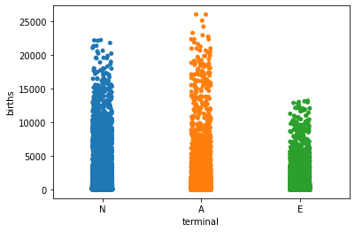

```python
# stripplot horizontal
df['terminal'] = df['name'].str[-1].str.upper()
letters = list('AEN')
var = df.loc[df['terminal'].isin(letters) & (df['year'] > 2000) & (df['country'] == 'us')]
sns.stripplot(data=var, x='terminal', y='births');
```

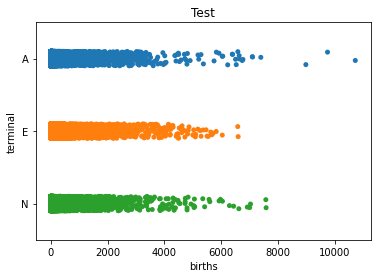

```python
# stripplot vertical
var = df.loc[df['terminal'].isin(letters) & (df['year'] > 2000) & (df['country'] == 'fr')]
ax = sns.stripplot(data=var, y='terminal', x='births');
ax.set_title('Test');
```

#### heatmap

Plot rectangular data as a color-encoded matrix.

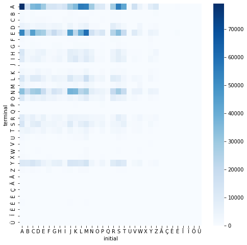

```python
# heatmap
fig, ax = plt.subplots(1, 1, figsize=(8, 8))
sns.heatmap(pd.crosstab(df['terminal'], df['initial']), cmap='Blues', ax=ax);
```

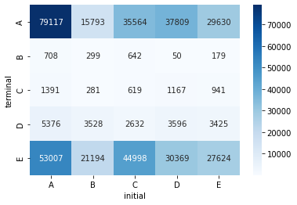

```python
tab = pd.crosstab(df['terminal'], df['initial']).iloc[:5, :5]
sns.heatmap(tab, cmap='Blues', annot=True, fmt='d');
```

## 5. Cartes : maplotlib, plotly, ipyleaflet

### 5.1 Cartes naives avec matplotlib

```python
# communes de France

df = pd.read_csv('correspondance-code-insee-code-postal.csv',
                sep=';')
df[['Latitude', 'Longitude']] = df['geo_point_2d'].str.extract('(.*), (.*)').astype(float)
df.shape
```

```
(36742, 19)
```

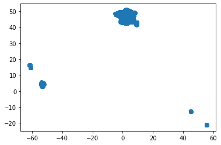

```python
# carte naive
plt.scatter(df['Longitude'], df['Latitude']);
```

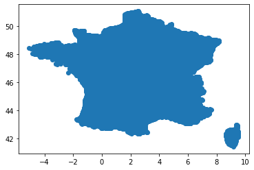

```python
# métro : projection cylindrique équidistante vs Mercator
metro = df.loc[df['Latitude'] > 40]
plt.scatter(metro['Longitude'], metro['Latitude']);
```

Prise en compte du relief.

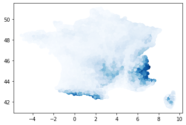

```python
# nuancier bleu
plt.scatter(metro["Longitude"],
            metro["Latitude"],
            c=metro["Altitude Moyenne"],
            cmap=plt.cm.Blues,
            edgecolors='none');
```

Avec tri des altitudes.

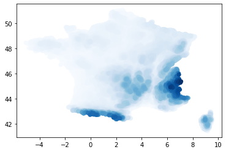

```python
# nuancier bleu avec tri des valeurs
metro = metro.sort_values("Altitude Moyenne")
plt.scatter(metro["Longitude"],
            metro["Latitude"],
            c=metro["Altitude Moyenne"],
            cmap=plt.cm.Blues,
            edgecolors='none');
```

Avec une autre palette de couleur et une colorbar.

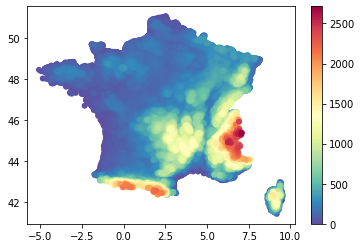

```python
# on utilise plt.cm.Spectral_r
var = plt.scatter(x=metro["Longitude"],
            y=metro["Latitude"],
            c=metro["Altitude Moyenne"],
            cmap=plt.cm.Spectral_r,
            edgecolors='none')
plt.colorbar(var);
```

**Remarque**

Il existe dans *matplotlib* (et *seaborn*) un système de palettes de couleurs :

- matplotlib : https://matplotlib.org/stable/tutorials/colors/colormaps.html
- seaborn : http://seaborn.pydata.org/tutorial/color_palettes.html

Les librairies gèrent également :

- Les palettes de couleurs de **ColorBrewer** : http://colorbrewer2.org
- Les 954 couleurs nommées de manière participative par l'initiative **xkcd** : https://xkcd.com/color/rgb/ Voir également le blog : https://blog.xkcd.com/2010/05/03/color-survey-results/

### 5.2 Cartes avec plotly

Plotly Python Open Source Graphing Library

Plotly's Python graphing library makes interactive, publication-quality graphs.

Voir : https://plotly.com/python/

La société canadienne plotly édite également la librairie **dash**.

Voir : https://plotly.com/dash/

```python
# import
from plotly.offline import iplot, init_notebook_mode
import colorlover as cl

# init
init_notebook_mode(connected=True)
```

```python
# pays
var = pd.read_html('https://www.geonames.org/countries/',
                   header=0,
                   keep_default_na=False)  # NA = North America
df = var[1]
df.shape
```

```
(250, 9)
```

Carte mondiale : programmation déclarative

```python
# carte mondiale
data = [{
        'type': 'choropleth',
        'locations': df['ISO-3166alpha3'],
        'z': df['Population'],
        'text': df['Country'],
        'colorscale': list(zip(np.linspace(0, 1, 9), cl.scales['9']['seq']['Reds'])),
        'autocolorscale': False,
        'reversescale': False,
        'marker': {
            'line': {
                'color': 'rgb(180,180,180)',
                'width': 0.5
            }},
        'colorbar':
            {'autotick': False,
            'title': 'Population'},
        }]

layout = {
    'title': '<br>Source:\
            <a href="https://www.geonames.org/countries/">\
            geonames</a>',
    'geo': {
        'showcountries': True,
        'showframe': False,
        'showcoastlines': False,
        'projection': {
            'type': 'mercator'  # 'mercator'
        }
    }
}


fig = {'data': data, 'layout': layout}
iplot(fig, validate=False, filename='d3-world-map')
```

[interactive chart not shown]

**Exercice n° 5**

- Ajoutez une colonne 'Densité'
- Affichez la densité en niveaux de bleus (cherchez une correction des données pour obtenir un affichage pertinent).
- Prenez une projection aléatoire parmi : 'equirectangular', 'mercator', 'orthographic', 'natural earth', 'kavrayskiy7', 'miller', 'robinson', 'eckert4', 'azimuthal equal area', 'azimuthal equidistant', 'conic equal area', 'conic conformal', 'conic equidistant', 'gnomonic', 'stereographic', 'mollweide', 'hammer', 'transverse mercator' en utilisant numpy.random.choice()

### 5.3 Geocoding avec geopy et cartes avec ipyleaflet

ipyleaflet provides interactive maps in the Jupyter notebook based on leaflet.js JavaScript library and OpenStreetMap.

Installation (in a shell):

```
conda install -c conda-forge geopy or pip install geopy

conda install -c conda-forge ipyleaflet or pip install ipyleaflet

jupyter nbextension enable --py --sys-prefix ipyleaflet
```

**geopy** : informations sur une adresse physique.

Voir : https://geopy.readthedocs.io/en/stable/index.html

```python
# mandatory if Python ssl.SSLError occurs
#import ssl
#import certifi
#ctx = ssl.create_default_context(cafile=certifi.where())
#geopy.geocoders.options.default_ssl_context = ctx
#import geopy

from geopy.geocoders import Nominatim

geolocator = Nominatim(user_agent='telecom_paris', timeout=7)
location = geolocator.geocode('19 Place Marguerite Perey, 91120 Palaiseau, France')
location.raw
```

```
{'place_id': 282421393,
 'licence': 'Data © OpenStreetMap contributors, ODbL 1.0. https://osm.org/copyright',
 'osm_type': 'relation',
 'osm_id': 9903423,
 'boundingbox': ['48.7123423', '48.7134647', '2.1988453', '2.2015918'],
 'lat': '48.7129116',
 'lon': '2.1998893037725673',
 'display_name': 'Télécom Paris, 19, Place Marguerite Perey, La Vauve - École Polytechnique, Campus Urbain de Paris-Saclay, Palaiseau, Essonne, Île-de-France, France métropolitaine, 91120, France',
 'class': 'building',
 'type': 'college',
 'importance': 1.1725057412006172}
```

```python
# get latitude and longitude
lat, lon = location.raw['lat'], location.raw['lon']
lat, lon
```

```
('48.7129116', '2.1998893037725673')
```

**Plan**

```python
# demo
from ipyleaflet import Map

# map arround 48.71, 2.20
m = Map(center=(lat, lon), zoom=18)
m
```

**Image satellite**

```python
# satellite map
from datetime import datetime, timedelta
from ipyleaflet import basemaps, basemap_to_tiles

# satellite map for yesterday
# NASA's Global Imagery Browse Services
yesterday = datetime.now() - timedelta(days=1)
nasa = basemap_to_tiles(basemaps.NASAGIBS.ModisTerraTrueColorCR, yesterday.strftime('%Y-%m-%d'))
m = Map(layers=(nasa, ), center=(lat, lon), zoom=4)

m
```

**Autre carte...**

```python
# villes
df = pd.read_csv('cities500.zip',
                 sep='\t',header=None,
                 keep_default_na=False,  # NA = North America
                 na_values=['', -9999],
                 names=['geonameid', 'name', 'asciiname', 'alternatenames', 'latitude',
                        'longitude', 'feature class', 'feature code', 'country code',
                        'cc2', 'admin1 code', 'admin2 code', 'admin3 code', 'admin4 code',
                        'population', 'elevation', 'dem', 'timezone', 'modification date'],
                        dtype={'admin1 code': str,
                               'admin2 code': str,
                               'admin3 code': str,
                               'admin4 code': str})
df.shape
```

```
(197249, 19)
```

```python
# map with markers

from ipyleaflet import Marker, LayerGroup

watercolor = basemap_to_tiles(basemaps.Stamen.Watercolor)
m = Map(layers=(watercolor, ), center=(50, 50), zoom=1)

# add markers for cities with population >= 3M
df2 = df.loc[df['population'] >= 3e6]
layers = []
for i, row in df2.iterrows():
    marker = Marker(location=(row['latitude'], row['longitude']),
                    draggable=False,
                    title=row['name'])
    layers.append(marker)
layer_group = LayerGroup(layers=layers)
m.add_layer(layer_group)

m
```